# EvoGeno_Sept14

Melise Edwards

9/14/2020

```r
report_03_11_2020 <-   read_csv(url("https://raw.githubusercontent.com/CSSEGISandData/COVID-19/master/csse_covid_19_data/csse_covid_19_daily_reports/03-11-2020.csv")) %>%
  rename(Country_Region = "Country/Region", Province_State = "Province/State")
head(report_03_11_2020)
```

```
## # A tibble: 6 x 8
##   Province_State Country_Region `Last Update`       Confirmed Deaths Recovered
##   <chr>          <chr>          <dttm>                  <dbl>  <dbl>     <dbl>
## 1 Hubei          China          2020-03-11 10:53:02     67773   3046     49134
## 2 <NA>           Italy          2020-03-11 21:33:02     12462    827      1045
## 3 <NA>           Iran           2020-03-11 18:52:03      9000    354      2959
## 4 <NA>           Korea, South   2020-03-11 21:13:18      7755     60       288
## 5 France         France         2020-03-11 22:53:03      2281     48        12
## 6 <NA>           Spain          2020-03-11 20:53:02      2277     54       183
## # ... with 2 more variables: Latitude <dbl>, Longitude <dbl>
```

```r
str(report_03_11_2020)
```

```
## tibble [216 x 8] (S3: spec_tbl_df/tbl_df/tbl/data.frame)
##  $ Province_State: chr [1:216] "Hubei" NA NA NA ...
##  $ Country_Region: chr [1:216] "China" "Italy" "Iran" "Korea, South" ...
##  $ Last Update   : POSIXct[1:216], format: "2020-03-11 10:53:02" "2020-03-11 21:33:02" ...
##  $ Confirmed     : num [1:216] 67773 12462 9000 7755 2281 ...
##  $ Deaths        : num [1:216] 3046 827 354 60 48 ...
##  $ Recovered     : num [1:216] 49134 1045 2959 288 12 ...
##  $ Latitude      : num [1:216] 31 43 32 36 46.2 ...
##  $ Longitude     : num [1:216] 112.27 12 53 128 2.21 ...
##  - attr(*, "spec")=
##   .. cols(
##   ..   `Province/State` = col_character(),
##   ..   `Country/Region` = col_character(),
##   ..   `Last Update` = col_datetime(format = ""),
##   ..   Confirmed = col_double(),
##   ..   Deaths = col_double(),
##   ..   Recovered = col_double(),
##   ..   Latitude = col_double(),
##   ..   Longitude = col_double()
##   .. )
```

```r
view(report_03_11_2020)
```

```r
library(DT)
```

```r
datatable(report_03_11_2020)
```

|  | Province_State | Country_Region | Last Update | Confirmed | Deaths | Recovered | Latitude | Longitude |
| --- | --- | --- | --- | --- | --- | --- | --- | --- |
| 1 | Hubei | China | 2020-03-11T10:53:02Z | 67773 | 3046 | 49134 | 30.9756 | 112.2707 |
| 2 |  | Italy | 2020-03-11T21:33:02Z | 12462 | 827 | 1045 | 43 | 12 |
| 3 |  | Iran | 2020-03-11T18:52:03Z | 9000 | 354 | 2959 | 32 | 53 |
| 4 |  | Korea, South | 2020-03-11T21:13:18Z | 7755 | 60 | 288 | 36 | 128 |
| 5 | France | France | 2020-03-11T22:53:03Z | 2281 | 48 | 12 | 46.2276 | 2.2137 |
| 6 |  | Spain | 2020-03-11T20:53:02Z | 2277 | 54 | 183 | 40 | -4 |
| 7 |  | Germany | 2020-03-11T19:13:17Z | 1908 | 3 | 25 | 51 | 9 |
| 8 | Guangdong | China | 2020-03-11T10:13:06Z | 1356 | 8 | 1282 | 23.3417 | 113.4244 |
| 9 | Henan | China | 2020-03-11T08:13:09Z | 1273 | 22 | 1249 | 33.882 | 113.614 |
| 10 | Zhejiang | China | 2020-03-11T09:33:12Z | 1215 | 1 | 1195 | 29.1832 | 120.0934 |

[output cut: 206 more lines]

# Exercises (Part 1)

#### 1. The format of the daily reports has changed over time. What are the differences between 3/13/2020, the Friday before spring break 2020 and yesterday 6 months later on 9/13/2020? Load the files into R and use str() and View() (or in the top right corner click on Environment and then the data frame.). Note the in the more recent dates they have changed the column headers so that it is no longer necessary to rename Province_State and Country_Region.

```r
report_03_13_2020 <-   read_csv(url("https://raw.githubusercontent.com/CSSEGISandData/COVID-19/master/csse_covid_19_data/csse_covid_19_daily_reports/03-13-2020.csv")) %>%
  rename(Country_Region = "Country/Region", Province_State = "Province/State")
str(report_03_13_2020)
```

```
## tibble [230 x 8] (S3: spec_tbl_df/tbl_df/tbl/data.frame)
##  $ Province_State: chr [1:230] "Hubei" "Guangdong" "Henan" "Zhejiang" ...
##  $ Country_Region: chr [1:230] "China" "China" "China" "China" ...
##  $ Last Update   : POSIXct[1:230], format: "2020-03-13 11:09:03" "2020-03-13 11:09:03" ...
##  $ Confirmed     : num [1:230] 67786 1356 1273 1215 1018 ...
##  $ Deaths        : num [1:230] 3062 8 22 1 4 ...
##  $ Recovered     : num [1:230] 51553 1296 1249 1197 1005 ...
##  $ Latitude      : num [1:230] 31 23.3 33.9 29.2 27.6 ...
##  $ Longitude     : num [1:230] 112 113 114 120 112 ...
##  - attr(*, "spec")=
##   .. cols(
##   ..   `Province/State` = col_character(),
##   ..   `Country/Region` = col_character(),
##   ..   `Last Update` = col_datetime(format = ""),
##   ..   Confirmed = col_double(),
##   ..   Deaths = col_double(),
##   ..   Recovered = col_double(),
##   ..   Latitude = col_double(),
##   ..   Longitude = col_double()
##   .. )
```

```r
report_09_13_2020 <- read_csv(url("https://raw.githubusercontent.com/CSSEGISandData/COVID-19/master/csse_covid_19_data/csse_covid_19_daily_reports/09-13-2020.csv"))
str(report_09_13_2020)
```

```
## tibble [3,954 x 14] (S3: spec_tbl_df/tbl_df/tbl/data.frame)
##  $ FIPS               : num [1:3954] NA NA NA NA NA NA NA NA NA NA ...
##  $ Admin2             : chr [1:3954] NA NA NA NA ...
##  $ Province_State     : chr [1:3954] NA NA NA NA ...
##  $ Country_Region     : chr [1:3954] "Afghanistan" "Albania" "Algeria" "Andorra" ...
##  $ Last_Update        : POSIXct[1:3954], format: "2020-09-14 04:26:09" "2020-09-14 04:26:09" ...
##  $ Lat                : num [1:3954] 33.9 41.2 28 42.5 -11.2 ...
##  $ Long_              : num [1:3954] 67.71 20.17 1.66 1.52 17.87 ...
##  $ Confirmed          : num [1:3954] 38716 11353 48254 1344 3388 ...
##  $ Deaths             : num [1:3954] 1420 334 1612 53 134 ...
##  $ Recovered          : num [1:3954] 31638 6569 34037 943 1301 ...
##  $ Active             : num [1:3954] 5658 4450 12605 348 1953 ...
##  $ Combined_Key       : chr [1:3954] "Afghanistan" "Albania" "Algeria" "Andorra" ...
##  $ Incidence_Rate     : num [1:3954] 99.5 394.5 110 1739.5 10.3 ...
##  $ Case-Fatality_Ratio: num [1:3954] 3.67 2.94 3.34 3.94 3.96 ...
##  - attr(*, "spec")=
##   .. cols(
##   ..   FIPS = col_double(),
##   ..   Admin2 = col_character(),
##   ..   Province_State = col_character(),
##   ..   Country_Region = col_character(),
##   ..   Last_Update = col_datetime(format = ""),
##   ..   Lat = col_double(),
##   ..   Long_ = col_double(),
##   ..   Confirmed = col_double(),
##   ..   Deaths = col_double(),
##   ..   Recovered = col_double(),
##   ..   Active = col_double(),
##   ..   Combined_Key = col_character(),
##   ..   Incidence_Rate = col_double(),
##   ..   `Case-Fatality_Ratio` = col_double()
##   .. )
```

#### 2. Many countries have multiple entries representing different regions (e.g. counties and states). To get the counts for a country we need to summarise the data. Use group_by() and summarize() to make a data frame (tibble) with total counts for each country.

```r
total_03_13_2020 <- report_03_13_2020 %>%
  group_by(Country_Region) %>%
  summarize(
    total_deaths = sum(Deaths),
    total_confirmed = sum(Confirmed),
    total_recovered = sum(Recovered)
    )
total_09_13_2020 <- report_09_13_2020 %>%
  group_by(Country_Region) %>%
  summarize(
    total_deaths=sum(Deaths),
    total_confirmed=sum(Confirmed),
    total_recovered=sum(Recovered)
  )
total_03_13_2020
```

```
## # A tibble: 125 x 4
##    Country_Region      total_deaths total_confirmed total_recovered
##    <chr>                      <dbl>           <dbl>           <dbl>
##  1 Afghanistan                    0               7               0
##  2 Albania                        1              33               0
##  3 Algeria                        2              26               8
##  4 Andorra                        0               1               0
##  5 Antigua and Barbuda            0               1               0
##  6 Argentina                      2              31               0
##  7 Armenia                        0               8               0
##  8 Aruba                          0               2               0
##  9 Australia                      3             200              23
## 10 Austria                        1             504               6
## # ... with 115 more rows
```

```r
total_09_13_2020
```

```
## # A tibble: 188 x 4
##    Country_Region      total_deaths total_confirmed total_recovered
##    <chr>                      <dbl>           <dbl>           <dbl>
##  1 Afghanistan                 1420           38716           31638
##  2 Albania                      334           11353            6569
##  3 Algeria                     1612           48254           34037
##  4 Andorra                       53            1344             943
##  5 Angola                       134            3388            1301
##  6 Antigua and Barbuda            3              95              91
##  7 Argentina                  11352          555537          419513
##  8 Armenia                      916           45862           41659
##  9 Australia                    816           26692           23463
## 10 Austria                      756           33159           26760
## # ... with 178 more rows
```

#### 3. To get counts for confirmed cases per U.S state use filter() to select US and group_by and summarize as above.

#### Total deaths for March 13, 2020

```r
report_03_13_2020 %>%
  filter(Country_Region =="US") %>%
  group_by(Province_State, Country_Region) %>%
  summarise(Deaths) %>%
  arrange(Deaths)
```

```
## # A tibble: 53 x 3
## # Groups:   Province_State [53]
##    Province_State       Country_Region Deaths
##    <chr>                <chr>           <dbl>
##  1 Alabama              US                  0
##  2 Alaska               US                  0
##  3 Arizona              US                  0
##  4 Arkansas             US                  0
##  5 Colorado             US                  0
##  6 Connecticut          US                  0
##  7 Delaware             US                  0
##  8 Diamond Princess     US                  0
##  9 District of Columbia US                  0
## 10 Grand Princess       US                  0
## # ... with 43 more rows
```

#### Total deaths for September 13, 2020

```r
report_09_13_2020 %>%
  filter(Country_Region=="US") %>%
  group_by(Province_State) %>%
  summarise(Deaths) %>%
  arrange(Deaths)
```

```
## # A tibble: 3,270 x 2
## # Groups:   Province_State [58]
##    Province_State Deaths
##    <chr>           <dbl>
##  1 Alabama             0
##  2 Alaska              0
##  3 Alaska              0
##  4 Alaska              0
##  5 Alaska              0
##  6 Alaska              0
##  7 Alaska              0
##  8 Alaska              0
##  9 Alaska              0
## 10 Alaska              0
## # ... with 3,260 more rows
```

#### 4. It will be difficult to make simple graphs with the data from all countries in the world or even the US states. Use arrange_by() and slice() to get just the top 10 countries for Deaths.

```r
top_10_March <- total_03_13_2020 %>%
  arrange(total_deaths) %>%
  slice_tail(n=10)

top_10_March
```

```
## # A tibble: 10 x 4
##    Country_Region total_deaths total_confirmed total_recovered
##    <chr>                 <dbl>           <dbl>           <dbl>
##  1 Netherlands              10             804               0
##  2 Switzerland              11            1139               4
##  3 Japan                    19             701             118
##  4 US                       47            2179              12
##  5 Korea, South             66            7979             510
##  6 France                   79            3667              12
##  7 Spain                   133            5232             193
##  8 Iran                    514           11364            2959
##  9 Italy                  1266           17660            1439
## 10 China                  3180           80945           64196
```

Could have also done arrange(desc(Deaths)) instead of slice_tail.

```r
top_10_Sept <- total_09_13_2020 %>%
  arrange(total_deaths) %>%
  slice_tail(n=10)

top_10_Sept
```

```
## # A tibble: 10 x 4
##    Country_Region total_deaths total_confirmed total_recovered
##    <chr>                 <dbl>           <dbl>           <dbl>
##  1 Iran                  23157          402029          346242
##  2 Spain                 29747          566326          150376
##  3 Peru                  30526          722832          559321
##  4 France                30903          402893           90445
##  5 Italy                 35610          287753          213634
##  6 United Kingdom        41717          370930            2146
##  7 Mexico                70821          668381          557381
##  8 India                 78586         4754356         3702595
##  9 Brazil               131625         4330455         3723206
## 10 US                   194071         6519573         2451406
```

### Now, we will switch to doing the ggplot2 data vis lesson using data carpentry website : https://datacarpentry.org/R-ecology-lesson/04-visualization-ggplot2.html

#### nevermind, moved to other link “Data Visualization using ggplot2” on main website

# Exercises (Part 2)

#### 5. Make plots using geom_point() of the 10 countries with the confirmed cases and deaths (two separate graphs) on 3/12/2020 and 9/12/2020.

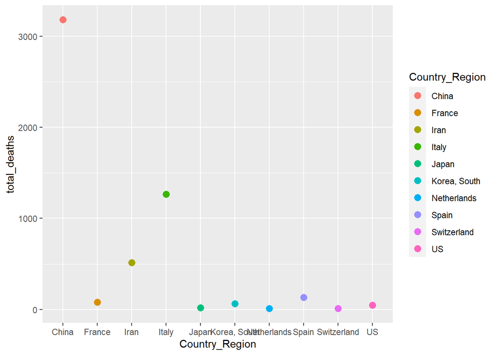

```r
#March

ggplot(data = top_10_March, aes(x = Country_Region, y = total_deaths)) +
  geom_point(aes(color = Country_Region), size = 3)
```

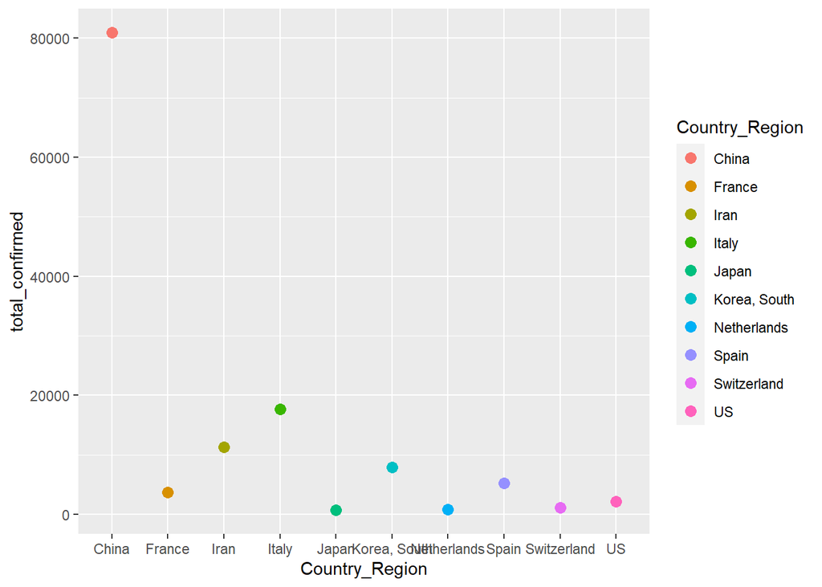

```r
ggplot(data = top_10_March, aes(x = Country_Region, y = total_confirmed)) +
  geom_point(aes(color = Country_Region), size = 3)
```

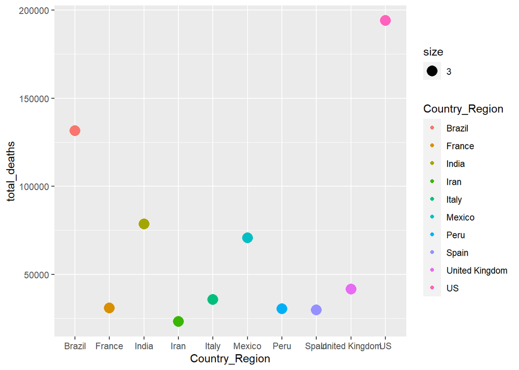

```r
# September

ggplot(data = top_10_Sept, aes(x = Country_Region, y = total_deaths)) +
  geom_point(aes(color = Country_Region, size = 3))
```

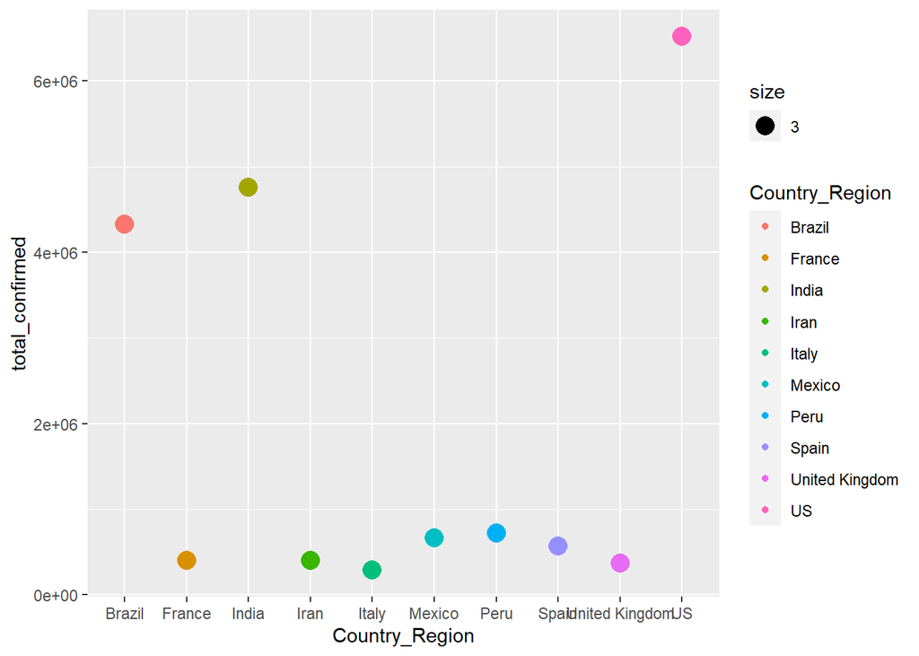

```r
ggplot(data = top_10_Sept, aes(x = Country_Region, y = total_confirmed)) +
  geom_point(aes(color = Country_Region, size = 3))
```

#### 6. Make using geom_bar of the 10 states with the most confirmed cases and deaths (two separate graphs) on 3/12/2020 and 9/12/2020.

Unclear, but I think this just means top 10 states of the US. Geom_point would have been better for this?

```r
#March

top10_US_march <- report_03_13_2020 %>%
  filter(Country_Region=="US") %>%
  group_by(Province_State) %>%
  summarise(Deaths) %>%
  arrange(desc(Deaths))
```

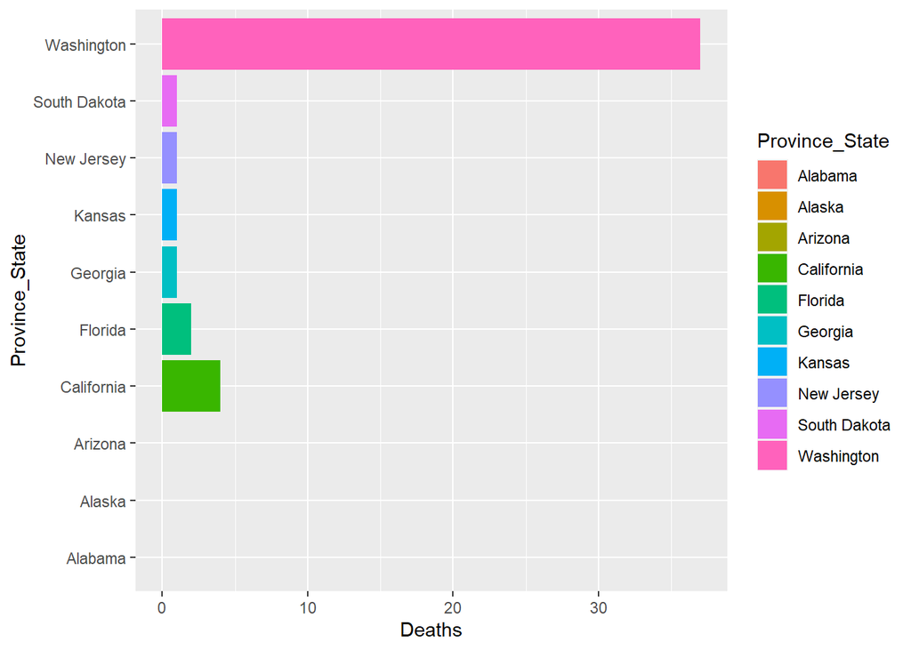

```r
top10_US_march <- top10_US_march %>%
  slice(1:10)

US_march_barplot <- ggplot(top10_US_march, aes(x = Deaths, y = Province_State))
US_march_barplot + geom_bar(stat = "identity", aes(fill = Province_State))
```

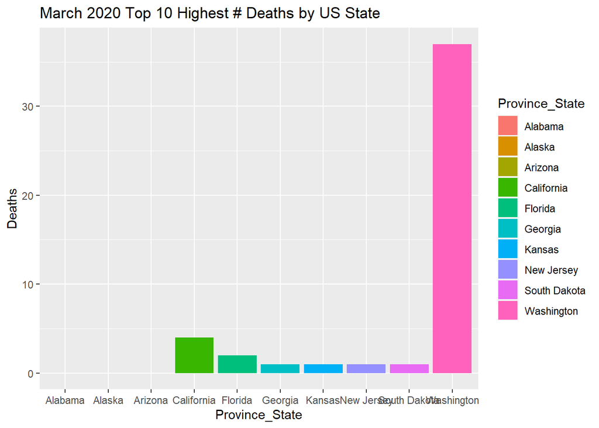

```r
#geom_col basically seems like the same output but easier to write

ggplot(top10_US_march, aes(x = Province_State, y = Deaths)) +
         geom_col(aes(fill = Province_State)) +
  ggtitle("March 2020 Top 10 Highest # Deaths by US State")
```

```r
# September

top10_us_sept1 <- report_09_13_2020 %>%
  filter(Country_Region=="US")

top10_us_sept1 <- top10_us_sept1 %>%
  group_by(Province_State) %>%
  summarise(all_deaths = sum(Deaths)) %>%
  arrange(desc(all_deaths)) %>%
  slice(1:10)
```

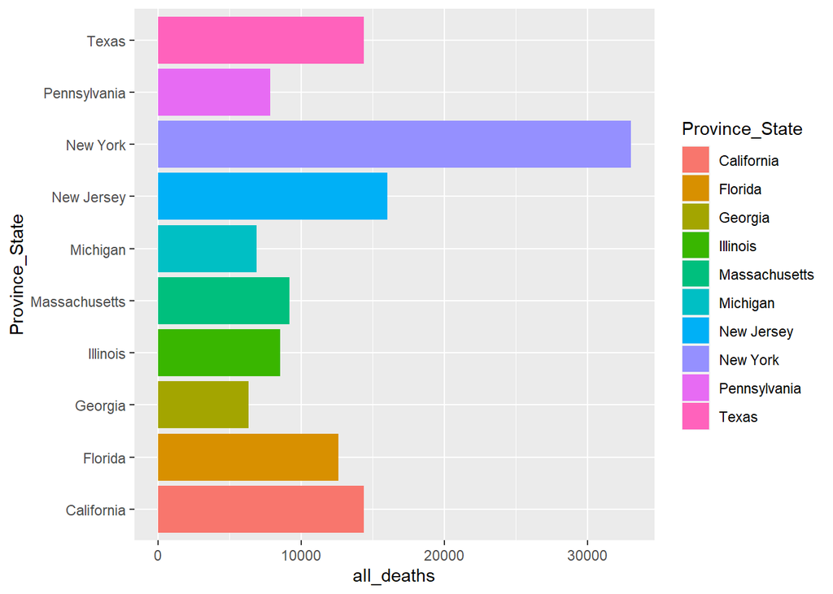

```r
# summarise let us take all the different states and sum them together
# now to graph


US_sept_barplot <- ggplot(top10_us_sept1, aes(x = all_deaths, y = Province_State))
US_sept_barplot + geom_bar(stat = "identity", aes(fill = Province_State))
```